# Testing the evolutionary consequences of sign epistasis

We detected several cases of strong sign epistasis for fertility in CeMEE RILs (Noble et al., 2017).

The evolution of populations in which these kinds of interactions are segregating should (all other things being equal) be sensitive to the frequency of the interacting alleles. We can test this with experimental evolution using selected RILs, and here we will simulate these experiments to get some idea of expected outcomes and the power to detect them.

For now, we’re ignoring the issue of whether these interactions are representative in outbred populations (where dominance is potentially important).

In brief, individual-based simulations below will generate replicate experimental populations that varying in frequency of a single focal interaction between alleles on two chromosomes (by mixing a single recombinant inbred line and the N2 reference). Outcrossing is assumed (without recombination - evolution is through segregation variances and selection).

We will model a polygenic trait with a specified genetic architecture and heritability (due to additive and pairwise interaction effects), using the effects estimated for the QTL. For simplicity, all epistatic heritability is due to the focal interaction, all additive heritability is due to sampled markers assigned in equal number to each chromosome. Below, we’re only considering a single interaction, between chromosomes III and IV.

###Setup First we load the required data:  
- Xld: LD pruned reference-based genotypes (we filter to SNVs segregating in A6140) - hfpass: locations of the interacting alleles  
- allp: fertility phenotype data, with genotypes for the major effect interactions (e.g., a1/b1 are the two interacting alleles at QTL 1)  
- pix: the names of these interacting pairs  
- peff: predicted additive and interaction effects for these alleles from linear regression

```r
load('simulationData.rda', verbose = T)
```

```
## Loading objects:
##   allp
##   pix
##   peff
##   hfpass
##   ecoefs
##   Xld
```

```r
source('sign_fns.R')

pos = Xld[[1]]
cmarkers = table(pos$chrom)
geno = data.frame(Xld[[2]])
lines = unique(ecoefs$line[ecoefs$pop=='A6140'])
geno = geno[,names(geno) %in% lines]
afs = apply(geno, 1, sum)/length(lines)*100
# filter genotypes, MAF > 3%
geno = geno[afs>3 & afs<97,]
```

Experimental and simulation parameters.

The ratio between census size (Ncensus; population size at the end of a generation) and the number of worms transferred to the next generation (NindPerRep; sampled in proportion to their predicted fitness) controls the intensity of selection.

```r
altFreq = c(0.25, 0.5, 0.75) # treatment: starting frequency of N2 alleles (varying F1 backcrosses)
Nreps=30           # experimental replicates (plates) per treatment
Ncensus=200        # plate census size
NindPerRep=100     # number of individuals sampled from Ncensus (based on relative fitness) each generation
NgenPerRep=10      # length of the experiment in generations
Nchrom=6           # number of chromosomes to model ()
NlociPerChrom=5    # number of additive background QTL per chromosome
Ncaus = NlociPerChrom*Nchrom
additiveH2 = 0.3   # genomic h2
epistaticH2 = 0.15 # heritability of segregating interactions on III/IV
```

Below we randomly sample some markers to generate the additive genetic background, make a phenotype based on the supplied additive and epistatic heritability values, and estimate the allelic effects for later use.

```r
# sample additive markers and generate phenotype with ~full heritability
x1 = simPheno(c(0.99, 0), Ncausal = Ncaus, X = geno, returnCausalIx = T)
# the positions of the sampled markers
cix = x1[[1]]
# phenotype values
phe = x1[[2]]
phe$line = rownames(phe)
phe = merge(phe, allp, sort=F)
# rescale to specified additive + epistatic heritability
phe$yy = phe$y * sqrt(additiveH2/var(phe$y))
# using the simulated additive phenotypes generated above,
# and the phenotypes predicted solely from the known epistatic interactions
phe$yy = phe$yy + phe$pred * sqrt(epistaticH2/var(phe$pred))
Ve = rnorm(nrow(phe))
Ve = Ve*sqrt((1-(additiveH2+epistaticH2))/var(Ve))
phe$yy = scale(phe$yy + Ve)
# estimate effects, heritability
# these models are used later to predict phenotypes
addfit = lm(sprintf('yy~%s', paste(paste0('x', 1:Ncaus), collapse='+')), phe)
intfit = lm(yy~a1*b1 + a2*b2 + a3*b2 + a4*b4 + a3*b5, phe)
cat(sprintf('Simulated additive/epistatic heritability = %.2f/%.2f\n', additiveH2, epistaticH2))
```

```
## Simulated additive/epistatic heritability = 0.30/0.15
```

```r
cat(sprintf('Realised heritability = %.2f/%.2f\n', summary(addfit)$adj, summary(intfit)$adj))
```

```
## Realised heritability = 0.21/0.18
```

```r
# get all allelic effects
ffit = lm(sprintf('yy~%s + a1*b1 + a2*b2 + a3*b2 + a4*b4 + a3*b5', paste(paste0('x', 1:Ncaus), collapse='+')), phe)
(acoefs = data.frame(beta=coef(summary(ffit))[,1]))
```

```
##                     beta
## (Intercept)  0.636188519
## x1           0.581647313
## x2          -0.013659347
## x3          -0.448730744
## x4           0.276622571
## x5          -0.170185251
## x6          -0.196422261
## x7          -0.138678844
## x8           0.202607163
## x9          -0.357018785
## x10          0.324800085
## x11         -0.153982882
## x12         -0.131342008
## x13          0.062387384
## x14         -0.517059496
## x15          0.014926188
## x16          0.087707999
## x17          0.059743540
## x18         -0.368791047
## x19          0.171118317
## x20          0.523161982
## x21         -0.080539082
## x22          0.275047571
## x23          0.316432897
## x24          0.085391065
## x25          0.188688683
## x26          0.052586690
## x27         -0.266118221
## x28         -0.694405077
## x29          0.004095478
## x30          0.192593816
## a1           0.665643150
## b1          -0.233168057
## a2          -0.014122810
## b2          -0.181111268
## a3          -0.178279437
## a4           0.517164385
## b4           0.495208579
## b5           0.627871722
## a1:b1       -1.790719434
## a2:b2       -0.741364853
## a4:b4       -1.162172268
## a3:b5       -0.828519531
```

```r
acoefs$variable = rownames(acoefs)
```

Below we select the RIL that we’re going to use as a source of non-reference alleles, and generate parental genotypes (haploid, but treated as homozygous diploid) in a format convenient for simulation.

```r
# selected RIL parent
P1 = "A6140L22"  # fixed for alternate alleles at a2/b2, a4/b4
focalpair = c('a4', 'b4')
addix = paste0('x', 1:Ncaus)
# additive markers per chromosome
(markers = split(addix, rep(1:Nchrom, each=NlociPerChrom)))
```

```
## $`1`
## [1] "x1" "x2" "x3" "x4" "x5"
##
## $`2`
## [1] "x6"  "x7"  "x8"  "x9"  "x10"
##
## $`3`
## [1] "x11" "x12" "x13" "x14" "x15"
##
## $`4`
## [1] "x16" "x17" "x18" "x19" "x20"
##
## $`5`
## [1] "x21" "x22" "x23" "x24" "x25"
##
## $`6`
## [1] "x26" "x27" "x28" "x29" "x30"
```

```r
intchr = c(T, T, F, T, F, T, F, T, F, T) # assigning interacting marker pairs to chromosome
imarkers = split(pix, intchr)
# RIL parent genotype
P1x = subset(phe, line==P1)[,c(addix, pix)]
# N2 parent
P2x = Ox = P1x; P2x[]=0
# split by chromosome/additive/interacting
P1chr = split(as.numeric(P1x[addix]), rep(1:Nchrom, each=NlociPerChrom))
P1int = split(as.numeric(P1x[pix]), intchr) # chr3, 4
P2chr = split(as.numeric(P2x[addix]), rep(1:Nchrom, each=NlociPerChrom))
P2int = split(rep(0, len(pix)), intchr) # chr3, 4
```

###Simulation Below is the main routine.

```r
# parallel threads
np=6
repev = dplyr::bind_rows(lapply(altFreq, function(q){
  print(q)
  o = dplyr::bind_rows(mclapply(1:Nreps, mc.cores=np, function(i){

    runRep <- function(){

      # expand G1 to NindPerRep, sampling chromosomes at a given reference allele frequency
      G1 <- function(P1chr, P2chr, N2freq = 0.5){

        F2s = dplyr::bind_rows(lapply(1:NindPerRep, function(x) {
          # segregation of chromosomes, no recombination, ignore hets
          toss = sample(c(0,1), Nchrom, prob = c(1-N2freq, N2freq), replace=T)==0
          Ox[addix] = unlist(lapply(1:Nchrom, function(i) if(toss[i]) P1chr[[i]] else P2chr[[i]]))
          toss = toss[3:4]
          for(i in 1:2) Ox[imarkers[[i]]] = if(toss[i]) P1int[[i]] else P2int[[i]]
          Ox
        }))
        F2s
      }

      # then, in subsequent generations, expand to Ncensus,
      # and sample NindPerRep in proportion to predicted fitness (+ residual noise)
      Gn <- function(popdf){

        addl = lapply(split(popdf, 1:nrow(popdf)), function(x) split(as.numeric(x[addix]), rep(1:Nchrom, each=NlociPerChrom)))
        intl = lapply(split(popdf, 1:nrow(popdf)), function(x) split(as.numeric(x[pix]), intchr))

        Fns = dplyr::bind_rows(lapply(1:Ncensus, function(x) {
          k = sample(1:len(addl), 2)
          toss = sample(c(0,1), Nchrom, replace=T)==0
          Ox[addix] = unlist(lapply(1:Nchrom, function(i) if(toss[i]) addl[[k[1]]][[i]] else addl[[k[2]]][[i]]))
          toss = toss[c(3,4)]
          for(i in 1:2) Ox[imarkers[[i]]] = if(toss[i]) intl[[k[1]]][[i]] else intl[[k[2]]][[i]]
          Ox
        }))

        # heritability is assumed constant
        Fns$add = predict(addfit, newdata = Fns)
        Fns$int = predict(intfit, newdata = Fns)
        Fns$y = Fns$add * sqrt(additiveH2/var(Fns$add))
        Fns$y = Fns$y + Fns$int * sqrt(epistaticH2/var(Fns$int))
        ee = rnorm(Ncensus); ee = ee*sqrt((1-(additiveH2+epistaticH2))/var(ee))
        Fns$y = Fns$y + ee
        Fns = Fns[!is.infinite(Fns$y),]

        # cut on predicted BV
        Fns[sample(Ncensus, NindPerRep, prob = Fns$y-min(Fns$y)),]
      }

      # iterate over generations,
      # recording fitness (w), phenotypic variance (sigma),
      # variance in additive breeding values (sigmaA),
      # and variance in epistatic effects (sigmaE),
      GX = G1(P1chr, P2chr, N2freq = q)
      afs = ws = sigma = sigmaA = sigmaE = focalg = NULL
      for(j in 1:NgenPerRep){
        cat('.')
        GX = Gn(GX)
        afs = rbind(afs, apply(GX[,c(addix, pix)], 2, sum)/nrow(GX))
        ws = c(ws, mean(GX$y))
        sigma = c(sigma, var(GX$y))
        sigmaA = c(sigmaA, var(GX$add))
        sigmaE = c(sigmaE, var(GX$int))
        focs = apply(GX[,focalpair], 1, paste0, collapse='')
        focalg = rbind(focalg, data.frame('00' = sum(focs=='00')/NindPerRep,
                                          '01' = sum(focs=='01')/NindPerRep,
                                          '10' = sum(focs=='10')/NindPerRep,
                                          '11' = sum(focs=='11')/NindPerRep))
      }
      cat(' ')
      cbind(rep=i, w=ws, sigma, sigmaA, sigmaE, G=1:NgenPerRep, reff = q, data.frame(afs), focalg)

    }

    oi=NULL
    while(is.null(oi)) oi = tryCatch(runRep(), error = function(e){NULL})
    oi

  }))
  cat('\n')
  o
}))
```

```
## [1] 0.25
##
## [1] 0.5
##
## [1] 0.75
```

```r
# predicted phenotypes from the full model
repev$pred = predict(ffit, newdata = repev)
# remove any fixed genotypes
nix = apply(repev, 2, sum)==0
evs = repev[,!nix]
evs$rep = factor(evs$rep)
evs$reff = factor(evs$reff)
head(evs)
```

```
##   rep        w     sigma     sigmaA    sigmaE G reff   x1   x4  x13  x17  x18
## 1   1 2.988331 0.8443371 0.07771640 0.6505730 1 0.25 0.83 0.83 0.75 0.74 0.74
## 2   1 3.210129 0.6633843 0.07516455 0.6285364 2 0.25 0.84 0.84 0.71 0.69 0.69
## 3   1 3.399338 0.7727874 0.07214641 0.6755024 3 0.25 0.85 0.85 0.69 0.68 0.68
## 4   1 3.331460 0.8426808 0.07304813 0.7243332 4 0.25 0.89 0.89 0.68 0.63 0.63
## 5   1 4.409399 0.6878358 0.04029967 0.7546447 5 0.25 0.97 0.97 0.65 0.62 0.62
## 6   1 4.741961 0.6526977 0.03480677 0.8075154 6 0.25 0.99 0.99 0.63 0.65 0.65
##    x23  x25  x27  x29  x30   a1   a2   b2   b3   a4   b4   b5  X00  X01  X10
## 1 0.75 0.75 0.76 0.76 0.76 0.74 0.75 0.74 0.74 0.75 0.74 0.74 0.04 0.21 0.22
## 2 0.80 0.80 0.72 0.72 0.72 0.69 0.71 0.69 0.69 0.71 0.69 0.69 0.10 0.19 0.21
## 3 0.84 0.84 0.65 0.65 0.65 0.68 0.69 0.68 0.68 0.69 0.68 0.68 0.10 0.21 0.22
## 4 0.80 0.80 0.64 0.64 0.64 0.63 0.68 0.63 0.63 0.68 0.63 0.63 0.08 0.24 0.29
## 5 0.80 0.80 0.68 0.68 0.68 0.62 0.65 0.62 0.62 0.65 0.62 0.62 0.10 0.25 0.28
## 6 0.88 0.88 0.65 0.65 0.65 0.65 0.63 0.65 0.65 0.63 0.65 0.65 0.09 0.28 0.26
##    X11     pred
## 1 0.53 2.003174
## 2 0.50 2.076165
## 3 0.47 2.124922
## 4 0.39 2.146824
## 5 0.37 2.231109
## 6 0.37 2.306043
```

The result is a data.frame with, for each experimental plate (1 generation of a given replicate lineage initiated at a given allele frequency of the focal interacting alleles):  
- *w*, predicted log fitness (fertility, in the same units as the input data - Poisson linear model coefficients)  
- *sigma*, phenotypic variance  
- *sigmaA*, variance in phenotype predicted from background additive effects  
- *sigmaE*, variance in phenotype predicted from focal loci (additive and interaction effects)  
- *rep* & *G*, replicate and generation number  
- *reff*, starting reference allele frequency  
- *x1-`30`*, allele frequencies at all (segregating) background additive markers  
- *a1-n* & *b1-n*, allele frequencies at all (segregating) interacting markers  
- *X00/X01/X10/X11*, frequencies of the four homozygous genotype classes at the focal interaction  
- *pred*, predicted phenotype from the plate-level allele frequencies (ignoring interactions)

###Results Now to plot some results. First, the mean frequencies of the focal alleles across all technical replicates for a given starting frequency - what we would see if we ignored interactions and simply measured the frequencies of causal alleles in each experimental plate.

Depending on sampling details, there can be a clear divergence in the slopes for a given allele as function of starting frequency - reflecting the effects of the interaction - but usually it’s a weak signal, at best.

We need to genotype individuals at the focal interaction(s) to get a more accurate and powerful picture of what’s going on. Even then, there’s a lot of variation among runs - without recombination, linked variation (``30` causal variants with randomly assigned effects) can work with or against the focal interaction effects.

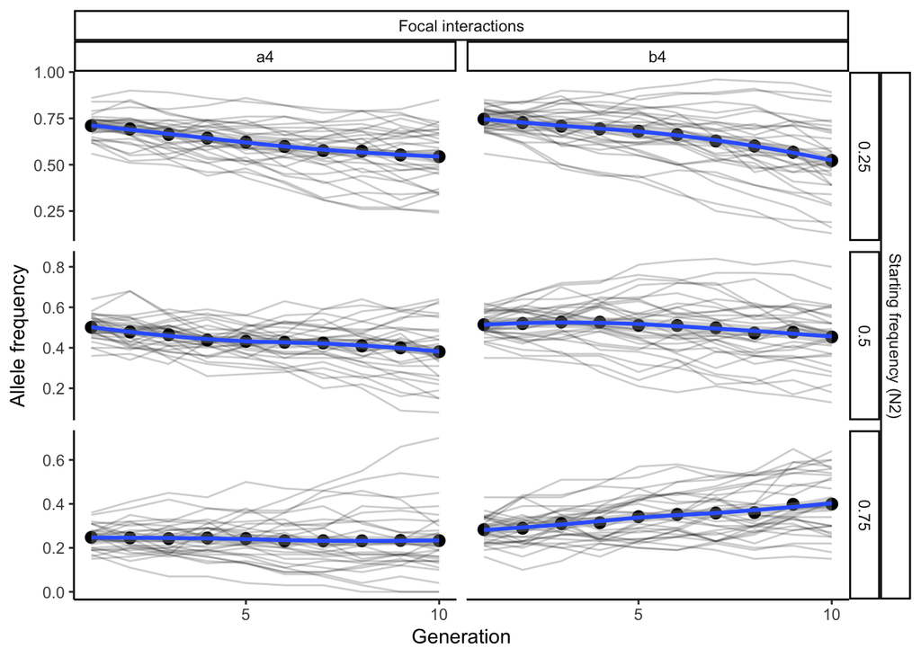

We can look at the individual allele frequency trajectories among replicates.

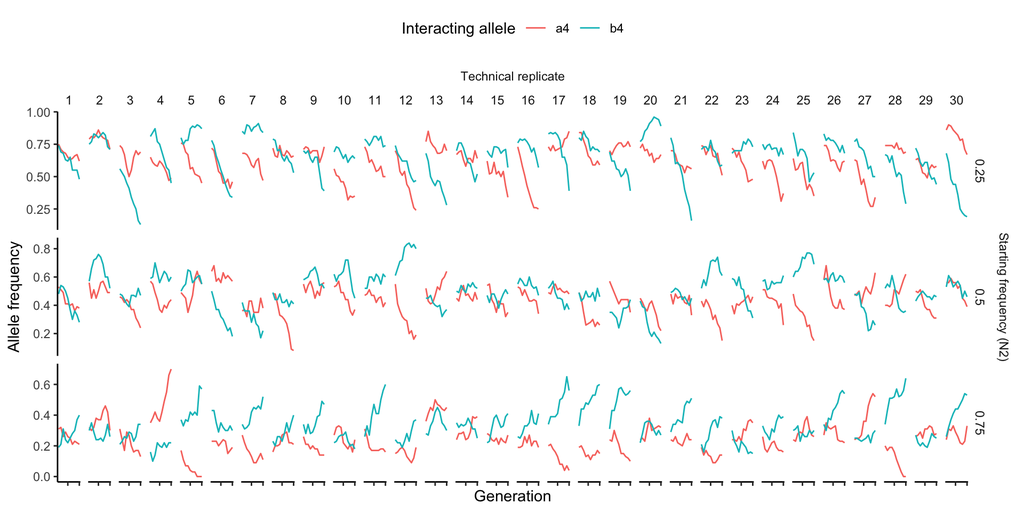

And summarise by averaging over technical replicates.

Below, we plot the mean change in frequency of the four genotype classes at the focal interaction, and test for differences in the slopes of these lines as a function of starting allele frequency.

This is an explicit test of our simple hypothesis, that selection on individual alleles that strongly interact through sign epistasis should depend on the starting allele frequency.

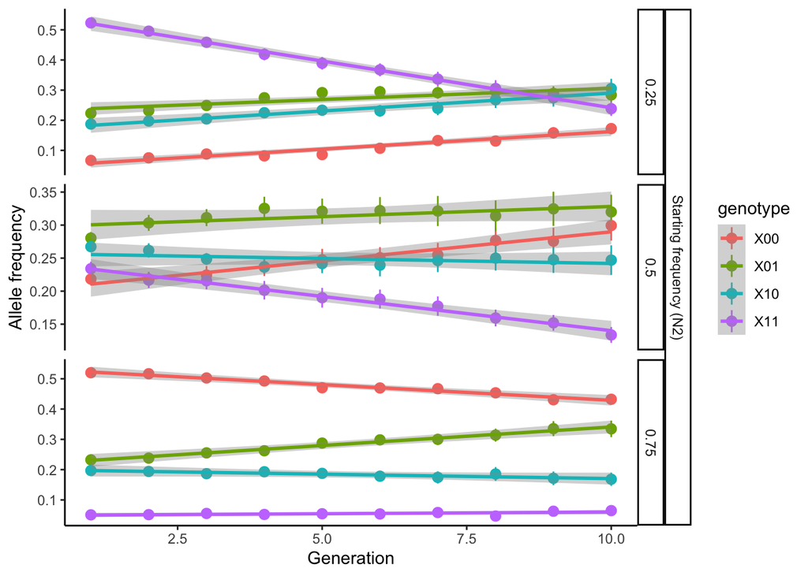

```r
# starting frequency-dependent trajectories of genotype classes at the focal interaction
afoc = reshape2::melt(evs[,c(1:7, which(names(evs) %in% c('X00', 'X01', 'X10', 'X11')))], 1:7, variable.name='genotype')
afoc$xlab = 'Starting frequency (N2)'

ggplot(afoc, aes(G, value, col = genotype)) +
  facet_nested(rows = vars(xlab, reff), scales='free') +
  stat_summary(fun.data = mean_se) + geom_smooth(method='lm') +
  theme_classic() + labs(x='Generation', y='Allele frequency')
```

```r
# fit a model (with temporal autocorrelation)
# testing dependence of genotype frequency on starting frequency
# (the genotype:G:ref interaction is the main term of interest)
cs1 = corAR1(0.7, form=~G|rep/reff/genotype)
# cs1. = Initialize(cs1, data = afoc)
# plot(corMatrix(cs1.)[[1]][1,])

# full mixed-effects model, random genotype slope within replicate
fiti = lme(asin(value)~genotype*G*reff, random=~genotype|rep, afoc, control=lmeControl(opt='optim'))
fit = update(fiti, correlation=cs1)
anova(fit)
```

```
##                 numDF denDF  F-value p-value
## (Intercept)         1  3547 4094.420  <.0001
## genotype            3  3547   17.411  <.0001
## G                   1  3547    0.000  0.9843
## reff                2  3547    0.062  0.9396
## genotype:G          3  3547   63.064  <.0001
## genotype:reff       6  3547  119.963  <.0001
## G:reff              2  3547    0.064  0.9378
## genotype:G:reff     6  3547   41.164  <.0001
```

*Predicted* evolutionary consequences (assuming no physiological limits, trade-offs). Obviously false, but potentially predictive of short-term evolution.

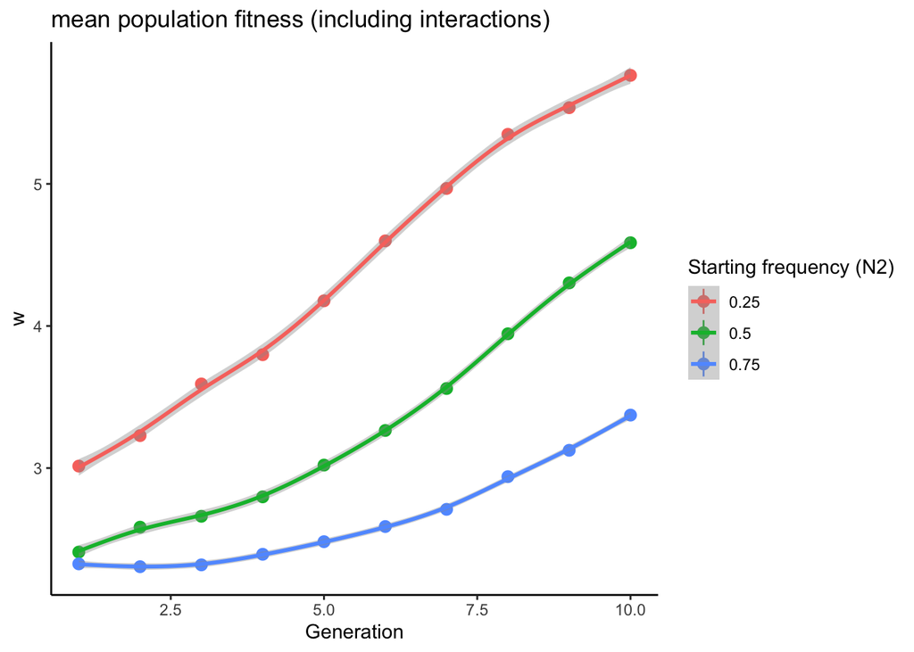

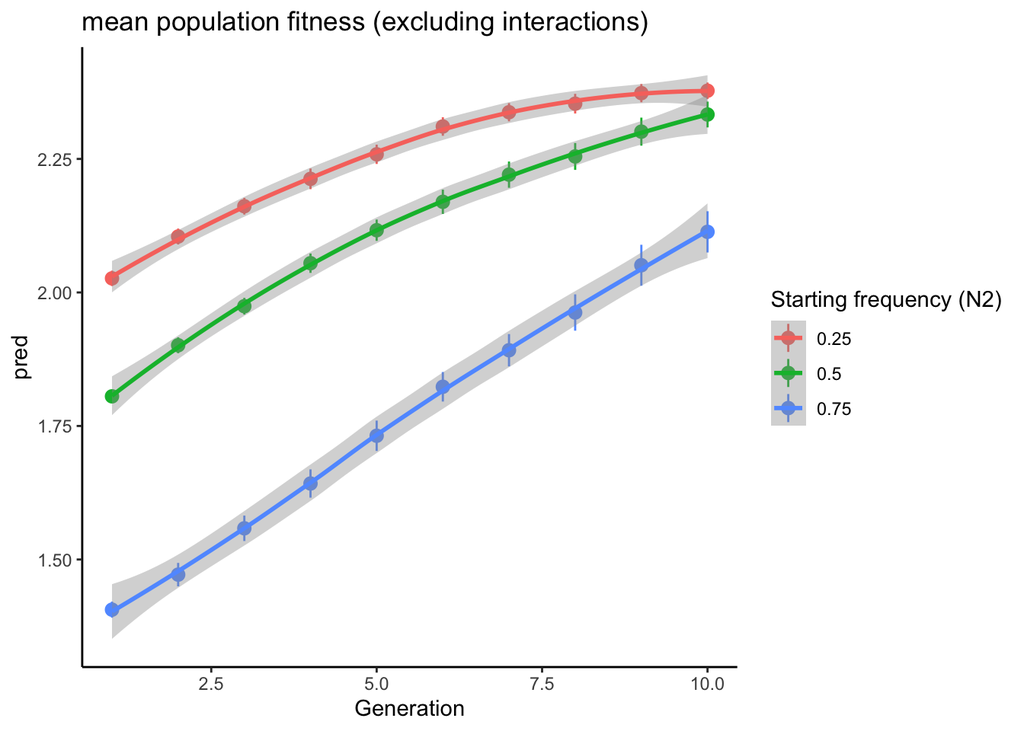

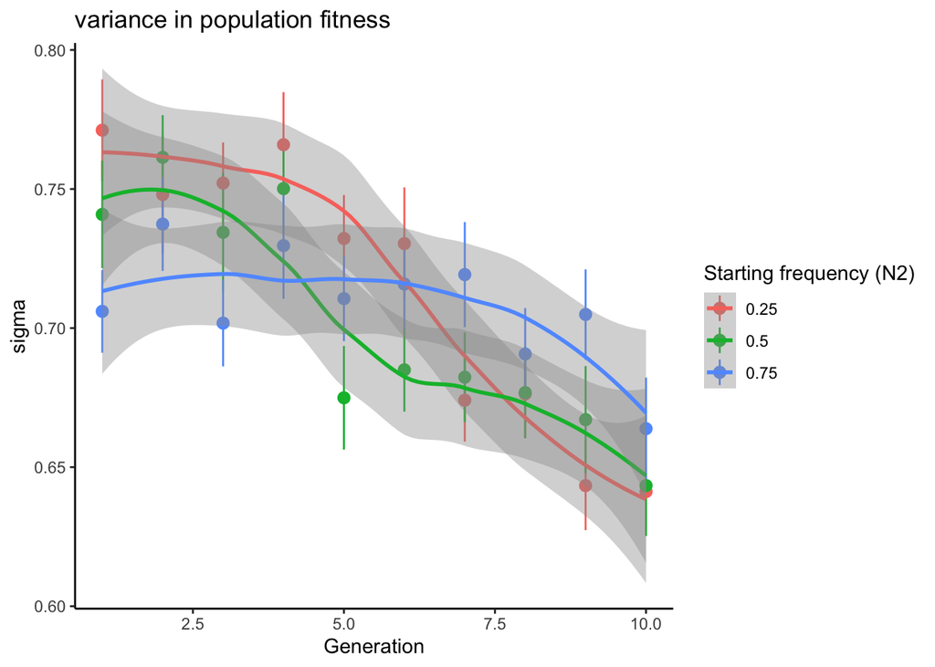